# R Notebook

```r
ages <- c(10, 20, 30, 40 , 50)
```

```r
summary(ages)
```

```
##    Min. 1st Qu.  Median    Mean 3rd Qu.    Max.
##      10      20      30      30      40      50
```

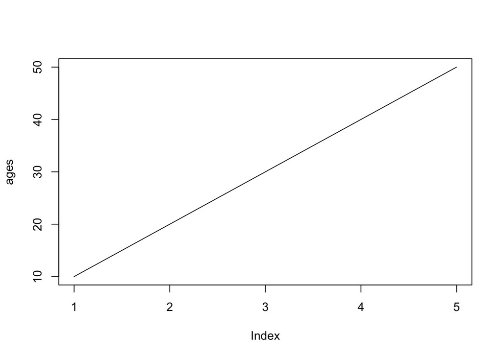

```r
plot(ages, type="l")
```

# Work with the data set

## Import the data set

```r
library(readr)
data <- read_csv("data/german_data_clean.csv")
summary(data$age_years)
```

```
##    Min. 1st Qu.  Median    Mean 3rd Qu.    Max.
##   19.00   27.00   33.00   35.55   42.00   75.00
```

```r
table(data$purpose)
```

```
##
##            business           car (new)          car (used) domestic appliances
##                  97                 234                 103                  12
##           education furniture/equipment              others    radio/television
##                  50                 181                  12                 280
##             repairs          retraining
##                  22                   9
```

```r
lm(credit_amount ~ age_years, data)
```

```
##
## Call:
## lm(formula = credit_amount ~ age_years, data = data)
##
## Coefficients:
## (Intercept)    age_years
##    2982.684        8.118
```

### Show measures of spread

Provide a summary

```r
summary(data$credit_amount)
```

```
##    Min. 1st Qu.  Median    Mean 3rd Qu.    Max.
##     250    1366    2320    3271    3972   18424
```

Visualize the data to detect possible outliers

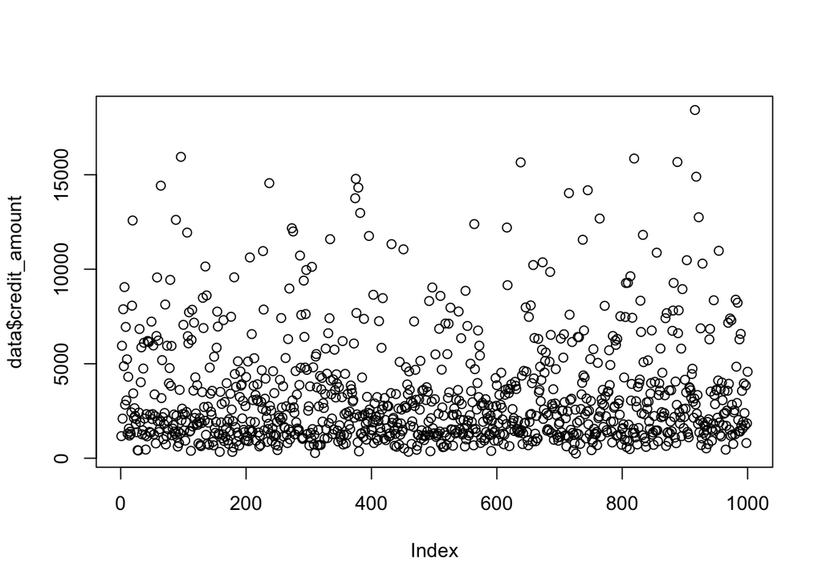

```r
plot(data$credit_amount)
```

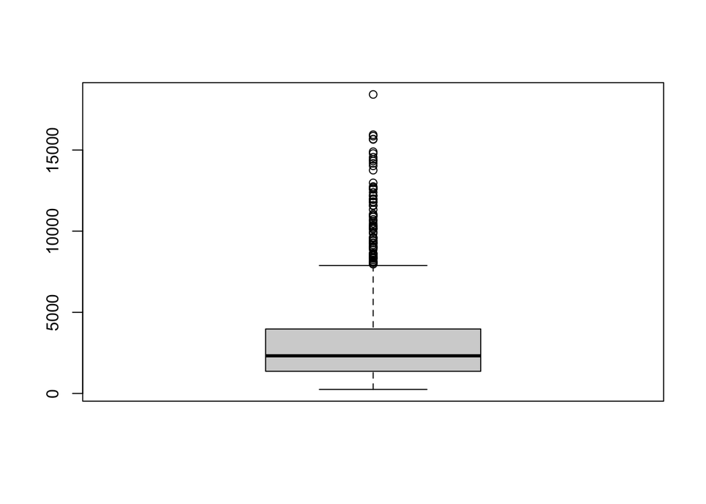

```r
boxplot(data$credit_amount)
```

Basic formula of an outlier:

Mean - 2 * sd

Mean + 2 * sd

```r
outlier_min <- mean(data$credit_amount) - (2* sd(data$credit_amount))
outlier_max <- mean(data$credit_amount) + (2* sd(data$credit_amount))
```

```r
print(outlier_min)
```

```
## [1] -2374.216
```

```r
print(outlier_max)
```

```
## [1] 8916.732
```

```r
data$is_outlier <- ifelse(data$credit_amount < outlier_min | data$credit_amount > outlier_max,
                          "outlier", "regular")
```

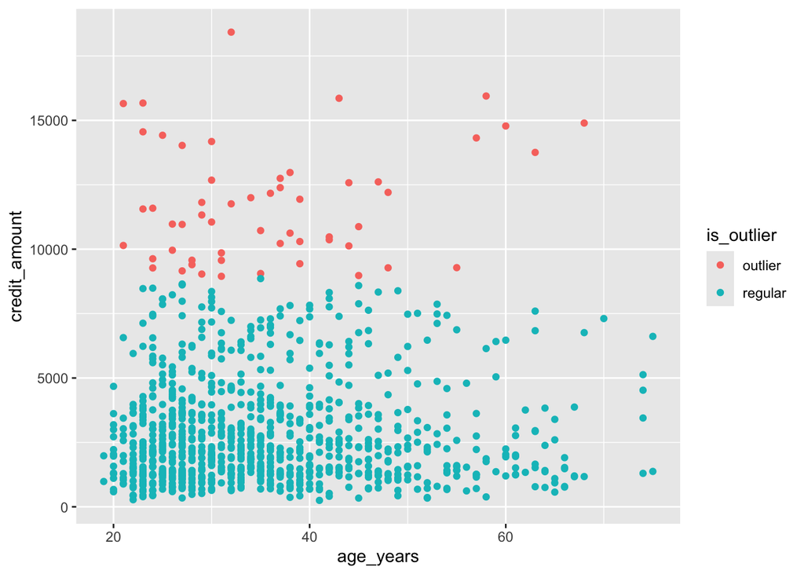

```r
library(ggplot2)

plot_1 <- ggplot(aes(x=age_years, y=credit_amount), data = data)
plot_1 + geom_point(aes(colour=is_outlier))
```

```r
mean(data$credit_amount)
```

```
## [1] 3271.258
```

```r
summary(data$credit_amount)
```

```
##    Min. 1st Qu.  Median    Mean 3rd Qu.    Max.
##     250    1366    2320    3271    3972   18424
```

### Percentiles

```r
# use the 'quantile' function to calculate percentiles
quantile(data$credit_amount, 0.95)
```

```
##    95%
## 9162.7
```

# Bi-variate statistics

### Using the Co-variance

```r
cov(data$age_years, data$credit_amount)
```

```
## [1] 1050.523
```

```r
cov(data$duration_months, data$credit_amount)
```

```
## [1] 21273.75
```

### Using the Correlation

```r
cor(data$age_years, data$credit_amount)
```

```
## [1] 0.03271642
```

```r
cor(data$duration_months, data$credit_amount)
```

```
## [1] 0.6249842
```

Causation research

```r
model_1 <- lm(credit_amount ~ duration_months, data=data)

summary(model_1)
```

```
##
## Call:
## lm(formula = credit_amount ~ duration_months, data = data)
##
## Residuals:
##     Min      1Q  Median      3Q     Max
## -5151.6 -1260.0  -432.9   653.2 13805.0
##
## Coefficients:
##                 Estimate Std. Error t value Pr(>|t|)
## (Intercept)      213.216    139.569   1.528    0.127
## duration_months  146.297      5.784  25.292   <2e-16 ***
## ---
## Signif. codes:  0 '***' 0.001 '**' 0.01 '*' 0.05 '.' 0.1 ' ' 1
##
## Residual standard error: 2205 on 998 degrees of freedom
## Multiple R-squared:  0.3906, Adjusted R-squared:   0.39
## F-statistic: 639.7 on 1 and 998 DF,  p-value: < 2.2e-16
```

# Binomial distribution

```r
dbinom(6, 10, 0.5)
```

```
## [1] 0.2050781
```

```r
trials <- 1:10

probabilities <- numeric(0)


for (x in trials){
  prob <- dbinom(x, 10, 0.5)
  probabilities <- append(probabilities, prob)
}

probabilities
```

```
##  [1] 0.0097656250 0.0439453125 0.1171875000 0.2050781250 0.2460937500
##  [6] 0.2050781250 0.1171875000 0.0439453125 0.0097656250 0.0009765625
```

Create a table to show the cumulative distribution

```r
probs_table <- data.frame(trial = trials,
                          probability = probabilities,
                          cumulative_probability = cumsum(probabilities))
```

Plot the single probability

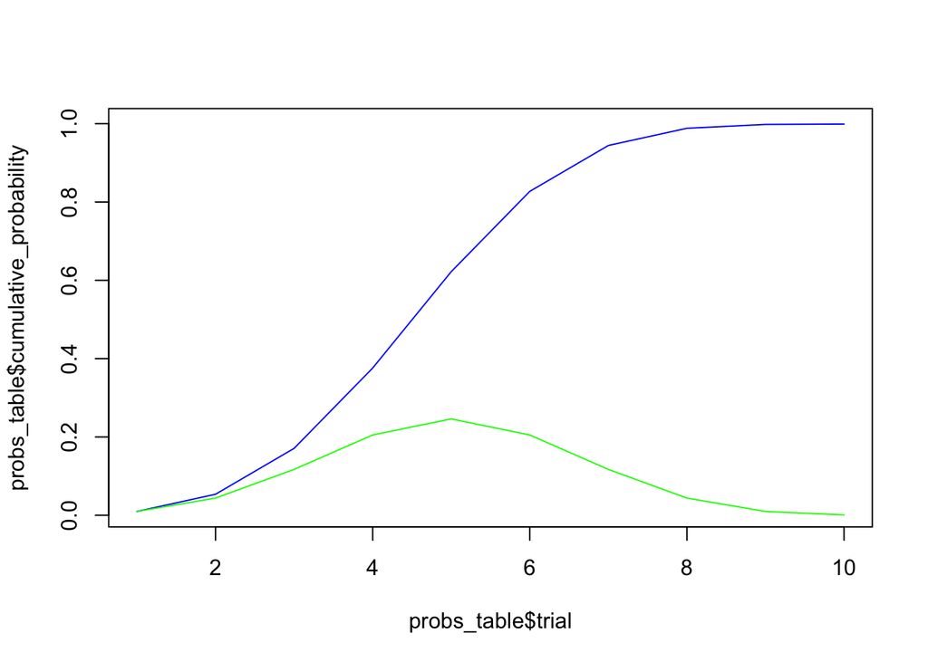

```r
plot(x = probs_table$trial,
     y = probs_table$cumulative_probability,
     type = "l",
     col = "blue")

lines(x = probs_table$trial,
      y = probs_table$probability,
      type = "l",
      col = "green")
```

# Normal distribution

## Display the distribution in R

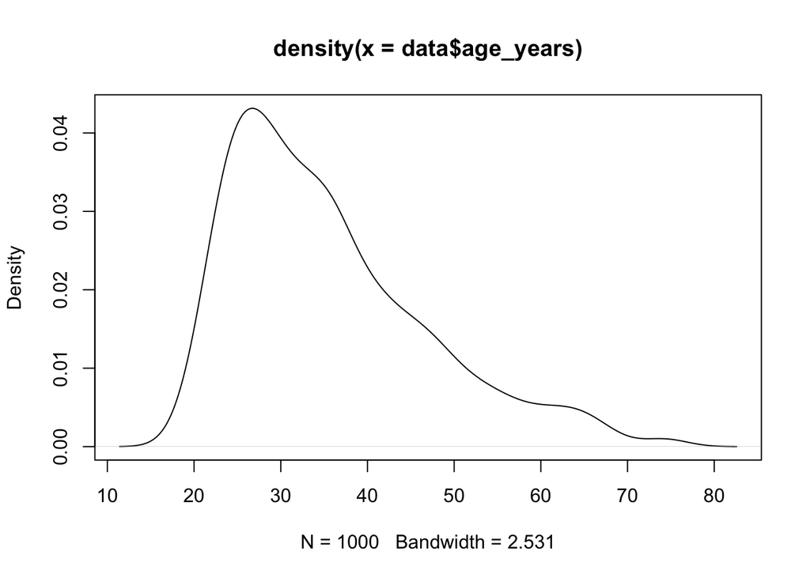

```r
plot(density(data$age_years))
```

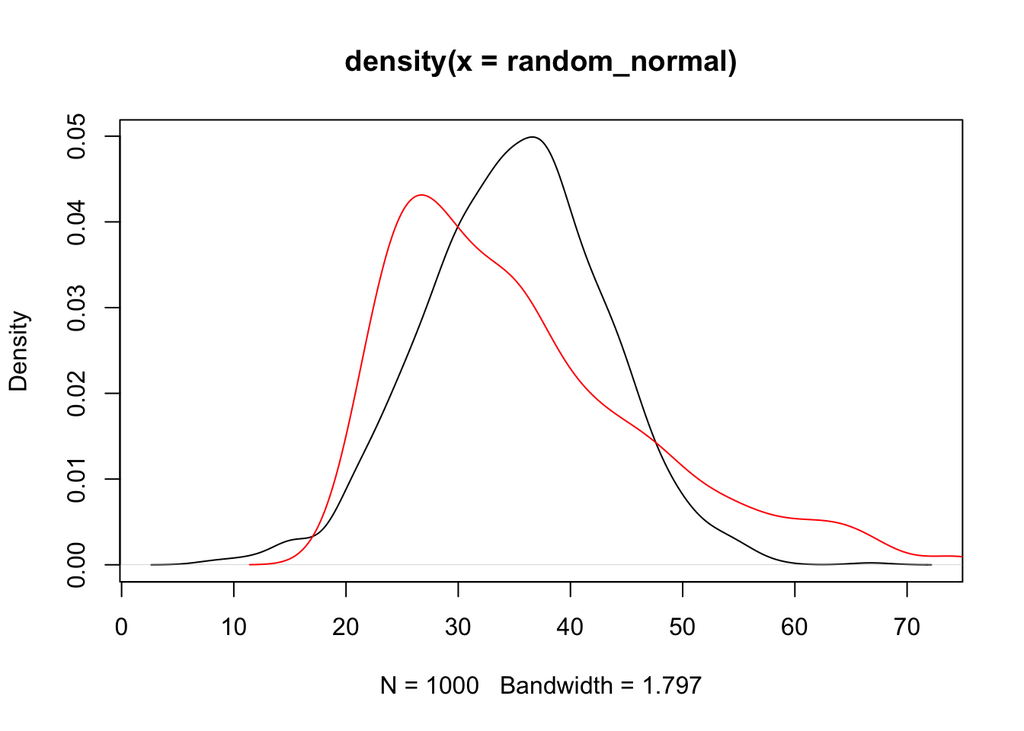

```r
random_normal <- rnorm(1000, 35, 8)
plot(density(random_normal))
lines(density(data$age_years), col="red")
```

### Manually calculate a z-score

```r
mean(data$age_years)
```

```
## [1] 35.546
```

```r
(50 - mean(data$age_years)) / sd(data$age_years)
```

```
## [1] 1.270629
```

```r
(35.546 - mean(data$age_years)) / sd(data$age_years)
```

```
## [1] -6.246272e-16
```

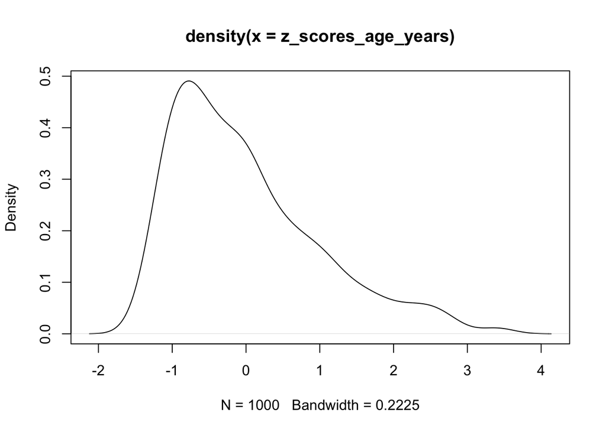

```r
z_scores_age_years <- numeric(0)

for (x in data$age_years){
  z_score <- (x - mean(data$age_years)) / sd(data$age_years)
  z_scores_age_years <- append(z_scores_age_years, z_score)
}

plot(density(z_scores_age_years))
```

## Check if the data is normally distributed

**H0:** The data is normally distributed.

**H1:** The data is **not** normally distributed.

```r
shapiro.test(data$age_years)
```

```
##
##  Shapiro-Wilk normality test
##
## data:  data$age_years
## W = 0.91747, p-value < 2.2e-16
```

`p-value` is significantly lower than `0.05`, so this variable is **not** normally distributed.

This means, we cannot choose a parametric.

- (So not `t-test`, no `anova`, but the **non**-parametric equivalents for these tests).

## First statistical test (2 groups)

Test if the average age of people having a loan for new cars if (significantly) different then people having a loan for used cars.

### Hypotheses

**H0:** The average age of people with loans for used cars is the same.

**H1:** The average age of people with loans for used cars is the **not** same.

### Check for normality of the variable

```r
# filter for only car-related purposes
data_cars <- data[data$purpose %in% c("car (new)", "car (used)"), ]
table(data_cars$purpose)
```

```
##
##  car (new) car (used)
##        234        103
```

```r
shapiro.test(data_cars$age_years)
```

```
##
##  Shapiro-Wilk normality test
##
## data:  data_cars$age_years
## W = 0.92305, p-value = 3.802e-12
```

The `p-value`, is lower than `0.05`, so the data is not normally distributed. We cannot use a parametric test.

### Decide the confidence level (p-value) for our test

For this research we choose a confidence level of `95%`, which means we have a critical boundary for the p-value of `0.05`

### Decide/execute the test that will be used

Based on the fact that the data is not normally distributed, we use for the alternative for a t-test, which is the Mann-Whitney U test, which is in R the `wilcox.test`

```r
wilcox_result <- wilcox.test(age_years ~ purpose, data = data_cars)
wilcox_result
```

```
##
##  Wilcoxon rank sum test with continuity correction
##
## data:  age_years by purpose
## W = 12076, p-value = 0.9758
## alternative hypothesis: true location shift is not equal to 0
```

```r
wilcox_result$p.value
```

```
## [1] 0.9757799
```

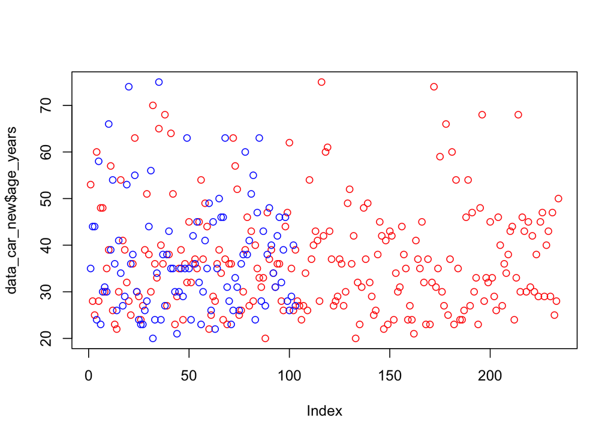

```r
data_car_new <- data_cars[data_cars$purpose == "car (new)",]
data_car_used <- data_cars[data_cars$purpose == "car (used)",]

plot(data_car_new$age_years, col="red")
points(data_car_used$age_years, col="blue")
```

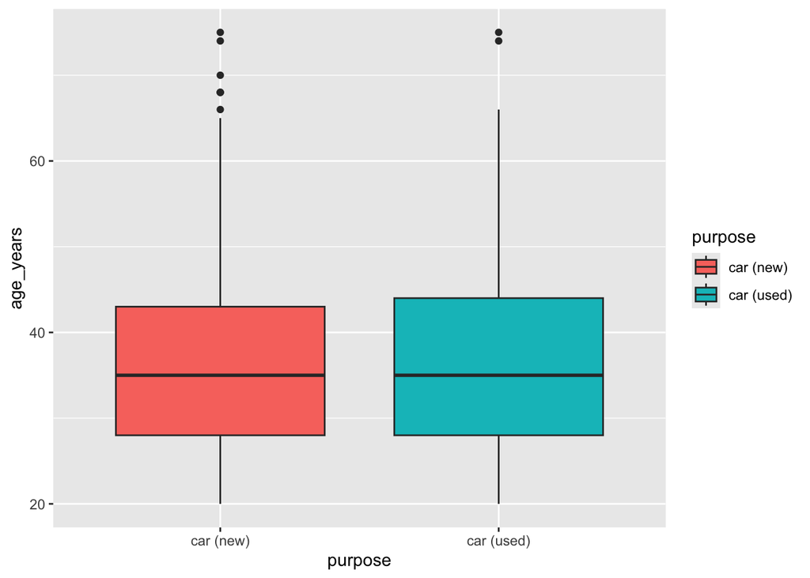

```r
boxplot_cars <- ggplot(aes(x=purpose, y = age_years), data = data_cars)
boxplot_cars + geom_boxplot(aes(fill=purpose))
```

### Analyse results of the test

The p-value is `0.9758`, which is larger than `0.05`, so there is not enough evidence to reject the **H0** hypothesis.

### Draw conclusions (about our hypotheses) for our test

The average age between people for loans with used or new cars, is not significantly different.

### What would the t-test

```r
t.test(data_car_used$age_years,
       data_car_new$age_years)
```

```
##
##  Welch Two Sample t-test
##
## data:  data_car_used$age_years and data_car_new$age_years
## t = 0.11602, df = 187.84, p-value = 0.9078
## alternative hypothesis: true difference in means is not equal to 0
## 95 percent confidence interval:
##  -2.603437  2.928804
## sample estimates:
## mean of x mean of y
##  37.25243  37.08974
```